# UFL Identity Tracker – Temporal Trends

Brian Wentzloff

2025-03-27

## 📥 Data (2 Weeks)

plays_per_point – How many offensive plays a team runs for each point scored. Lower values indicate efficient scoring with fewer plays per drive.

quarter_var – The variability in points scored per quarter. High variance can suggest inconsistency or momentum swings; low variance may indicate steady performance.

yards_per_play – Average yards gained per offensive play. A core measure of how productive a team is when they run or pass the ball.

yards_per_point – How many total yards a team needs to generate one point. Lower numbers signal that the team is turning yards into points effectively (good red zone/finish rate).

late_lift – The difference in points scored in the second half vs. the first half. Positive values suggest strong finishes or comeback potential; negative values may reveal fading late in games.

```r
identity_week1 <- tibble(
  week = 1,
  team = c("Washington", "SW Kansas", "Oregon"),
  plays_per_point = c(46/33, 39/63, 44/36),
  quarter_var = c(13, 14, 12),
  yards_per_play = c(206/46,200/39,274/44),
  yards_per_point = c(206/33,200/63,274/36),
  late_lift = c(7, -13, -12)
)

identity_week2 <- tibble(
  week = 2,
  team = c("Washington", "SW Kansas", "Oregon"),
  plays_per_point = c(33/35, 45/20, 45/28),
  quarter_var = c(29,7,14),
  yards_per_play = c(100/33,242/45,266/45),
  yards_per_point = c(100/33,242/20,266/28),
  late_lift = c(35,6,-16)
)

long_identity_df <- bind_rows(identity_week1, identity_week2)
```

## 📊 Trend Lines by Metric

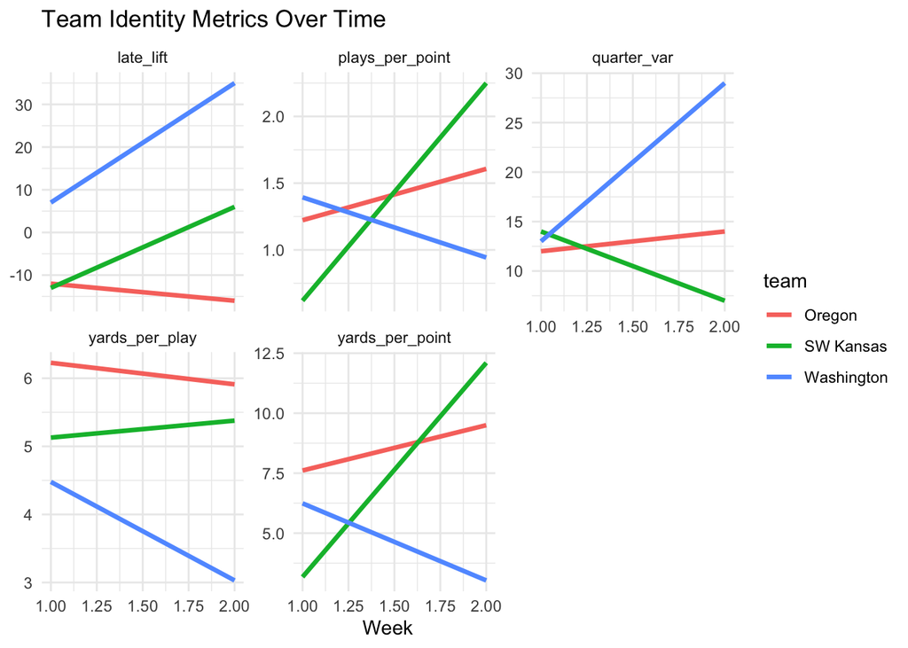

```r
long_identity_df %>%
  pivot_longer(cols = -c(week, team), names_to = "metric", values_to = "value") %>%
  ggplot(aes(x = week, y = value, color = team)) +
  geom_line(size = 1.2) +
  facet_wrap(~ metric, scales = "free_y") +
  theme_minimal() +
  labs(title = "Team Identity Metrics Over Time",
       x = "Week",
       y = NULL)
```

## 🧭 Identity Radar – Week Comparison

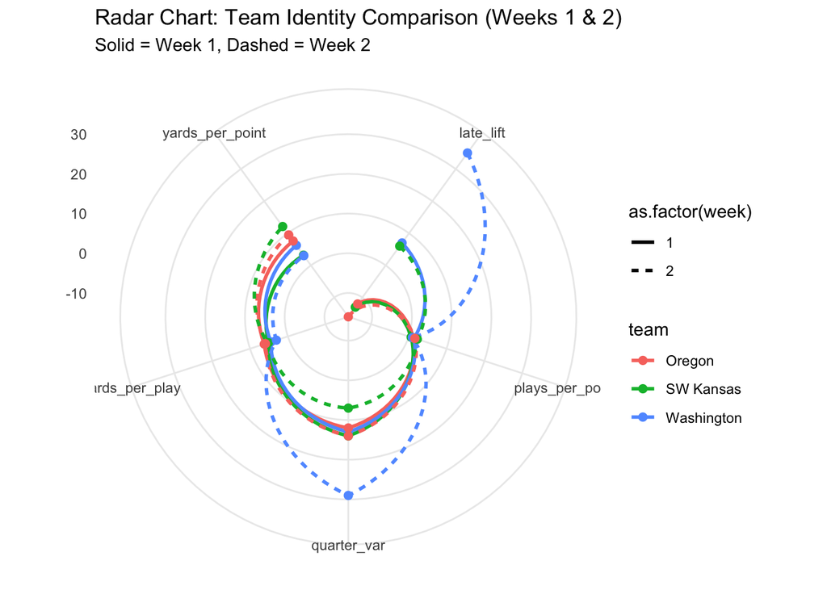

```r
radar_week1 <- identity_week1 %>%
  pivot_longer(-c(week, team), names_to = "metric", values_to = "value")

radar_week2 <- identity_week2 %>%
  pivot_longer(-c(week, team), names_to = "metric", values_to = "value")

radar_all <- bind_rows(radar_week1, radar_week2)

# Overlayed radar chart
ggplot(radar_all, aes(x = metric, y = value, group = interaction(team, week), color = team, linetype = as.factor(week))) +
  geom_line(size = 1) +
  geom_point(size = 2) +
  coord_polar() +
  theme_minimal() +
  labs(title = "Radar Chart: Team Identity Comparison (Weeks 1 & 2)",
       subtitle = "Solid = Week 1, Dashed = Week 2",
       x = NULL, y = NULL)
```

## 🧭 Week 1 vs. Week 2 Identity Shifts: What the Chart Reveals

This radar chart shows how each team’s playing style is evolving across key identity metrics. Solid lines represent Week 1, and dashed lines show Week 2, giving us a side-by-side view of how each team is shifting — whether tightening up or leaning further into their core tendencies.

Washington made the most dramatic change between weeks, particularly in late_lift, jumping sharply in second-half scoring. This could indicate either major halftime adjustments or a more explosive close-out strategy. However, they also saw a rise in quarter variance, suggesting streakier, more boom-or-bust performances overall.

## 📉 Delta Table: Week-over-Week Change

```r
delta_df <- identity_week2 %>%
  select(-week) %>%
  left_join(identity_week1 %>% select(-week), by = "team", suffix = c("_w2", "_w1")) %>%
  mutate(across(ends_with("_w1") & !starts_with("team"), ~ get(sub("_w1", "_w2", cur_column())) - ., .names = "delta_{.col}")) %>%
  select(team, starts_with("delta")) %>%
  mutate(across(-team, round, 2))
delta_df
```

```
## # A tibble: 3 × 6
##   team       delta_plays_per_point…¹ delta_quarter_var_w1 delta_yards_per_play…²
##   <chr>                        <dbl>                <dbl>                  <dbl>
## 1 Washington                   -0.45                   16                  -1.45
## 2 SW Kansas                     1.63                   -7                   0.25
## 3 Oregon                        0.38                    2                  -0.32
## # ℹ abbreviated names: ¹delta_plays_per_point_w1, ²delta_yards_per_play_w1
## # ℹ 2 more variables: delta_yards_per_point_w1 <dbl>, delta_late_lift_w1 <dbl>
```

## 🧪 Notes

- Each week’s identity metrics can be appended to `long_identity_df`.
- The delta table shows how each team is evolving — for identifying turning points.
- These tools will feed directly into the full UFL Identity Dashboard.